# Exercise Solutions – Plots using ggplot

Michael Hahsler

2021-01-25

## Introduction to ggplot2

The gg in `ggplot2` stands for [**grammar of graphics**](https://www.springer.com/statistics/computational/book/978-0-387-24544-7). The idea is that every graph is built from the same basic components:

- the data,
- a coordinate system, and
- visual marks representing the data (geoms).

In `ggplot2`, the components are combined using the `+` operator.

> `ggplot(data, mapping = aes(x = ..., y = ..., color = ...)) +` `geom_point() +` `coord_cartesian()`

Each `geom_X` uses a `stat_Y` function to calculate what is visualizes. For example, `geom_bar` uses `stat_count` to create a bar chart by counting how often each value appears in the data (see `? geom_bar`). `geom_point` just uses the stat `"identity"` to display the points using the coordinates as they are.

RStudio’s [Data Visualization Cheat Sheet](https://github.com/rstudio/cheatsheets/raw/master/data-visualization-2.1.pdf) offers a comprehensive overview of available components. A good introduction can be found in the [Chapter on Data Visualization](https://r4ds.had.co.nz/data-visualisation.html) of the free book [R for Data Science](https://r4ds.had.co.nz).

```r
library(ggplot2)
```

## 1. Plot a `sin(x)/x`.

*Hint:* Trigonometric functions in R use angles in radians (see `? sin`). 2 times pi is 360 degrees.

Create the data

```r
x <- seq(-6*pi, 6*pi, length.out = 100)
```

ggplot2 needs the data to be in a data.frame or tibble with all the data.

```r
dat <- data.frame(x = x, y = sin(x)/x)
head(dat)
```

```
##           x             y
## 1 -18.84956 -3.898172e-17
## 2 -18.46876 -2.012385e-02
## 3 -18.08796 -3.815130e-02
## 4 -17.70716 -5.137086e-02
## 5 -17.32636 -5.765016e-02
## 6 -16.94556 -5.576687e-02
```

We map `x` in the data.frame to the x-axis and `y` to the y-axis and then add a geom that produces a line representation. The Cartesian coordinate system is the default.

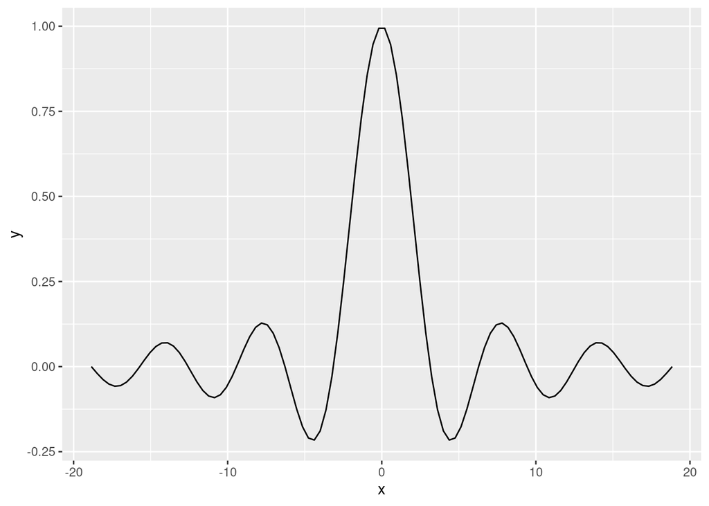

```r
ggplot(data = dat, mapping = aes(x = x, y = y)) +
  geom_line()
```

## 2. The ‘cars’ data set gives the speed of cars and the distances taken to stop. Note that the data were recorded in the 1920s. Plot the ‘cars’ data set as a scatter plot. Plot all data points with distances taken to stop greater than 80 in red.

```r
data(cars)
head(cars)
```

```
##   speed dist
## 1     4    2
## 2     4   10
## 3     7    4
## 4     7   22
## 5     8   16
## 6     9   10
```

basic version with points

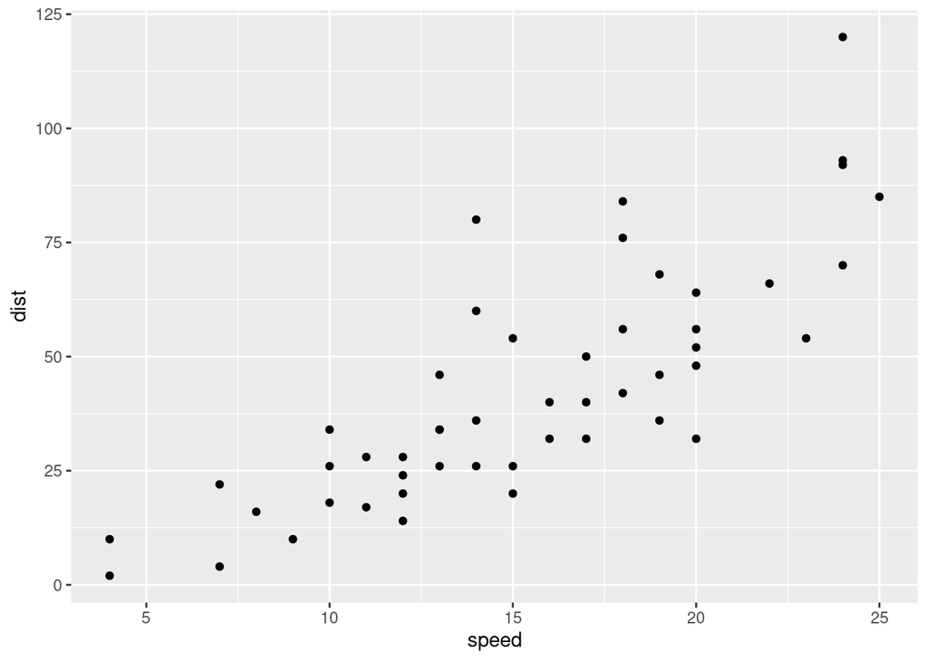

```r
ggplot(cars, mapping = aes(x = speed, y = dist)) +
  geom_point()
```

Add color as a mapping that is only used by `geom_points`. Mappings defined in `ggplot` are used by all geoms of the graph.

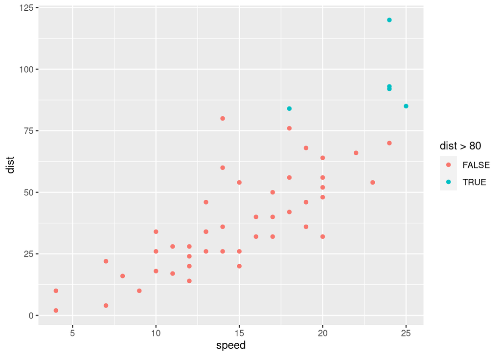

```r
ggplot(cars, mapping = aes(x = speed, y = dist)) +
  geom_point(mapping = aes(color = dist > 80))
```

define the colors using a manual color scale

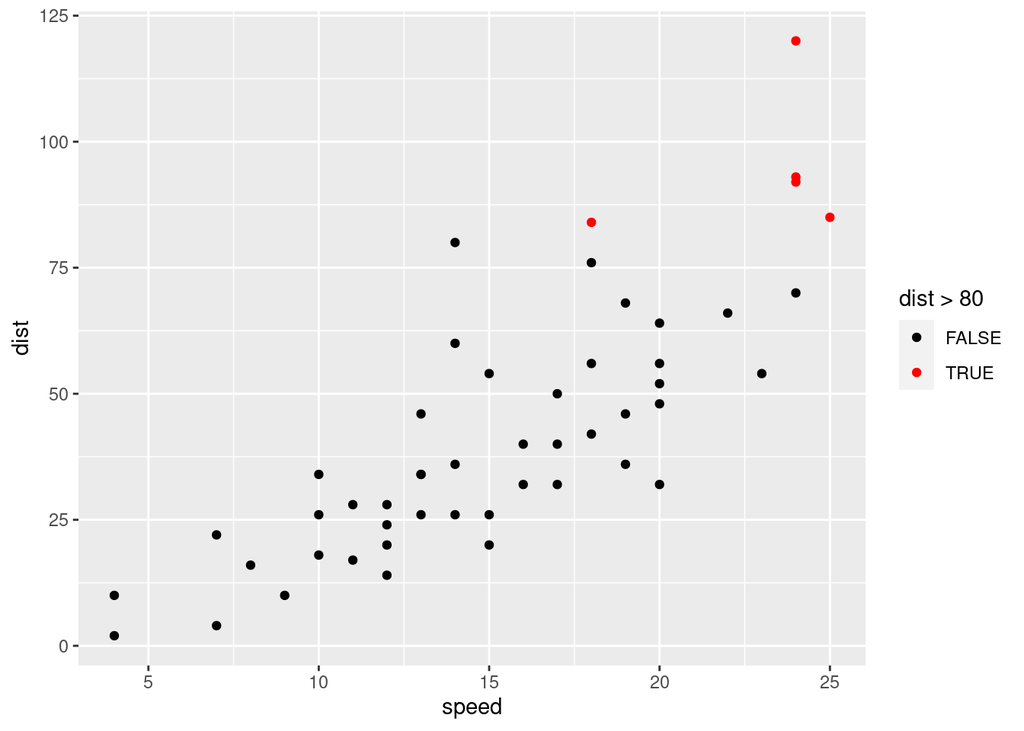

```r
ggplot(cars, mapping = aes(x = speed, y = dist)) +
  geom_point(mapping = aes(color = dist > 80)) +
  scale_color_manual(values = c("black", "red"))
```

add a second geom that produces a smoothed line (default is a local polynomial regression).

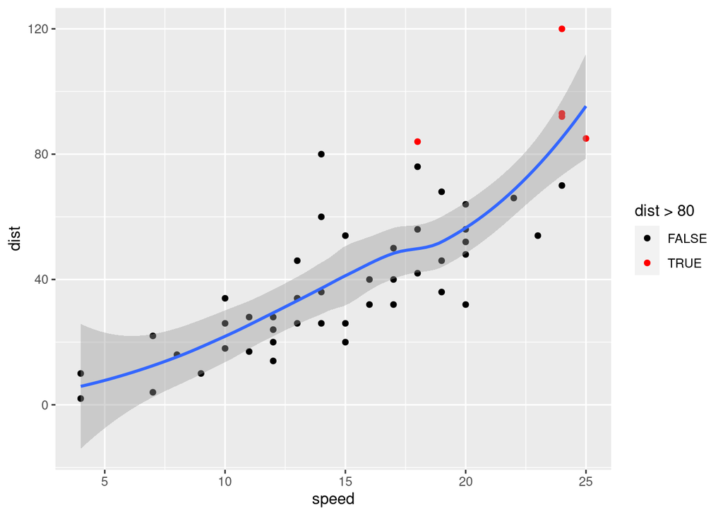

```r
ggplot(cars, mapping = aes(x = speed, y = dist)) +
  geom_point(mapping = aes(color = dist > 80)) +
  scale_color_manual(values = c("black", "red")) +
  geom_smooth()
```

## 3. Plot histograms for speed and dist in ‘cars’.

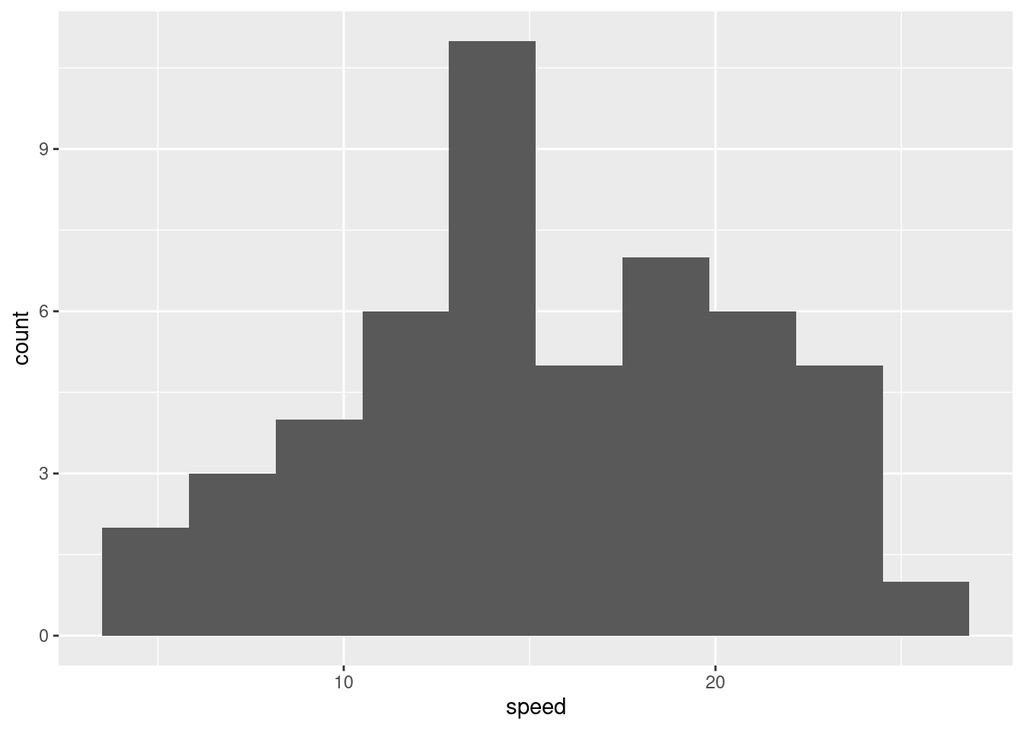

```r
ggplot(cars, aes(x = speed)) +
  geom_histogram(bins = 10)
```